# lab6 Assignment

Somnath Mukherjee

March 6, 2019

### Lab set-up

```r
#read input file
liver = read.table(here('lab6','data','data6.txt'), header = T, na.strings = ".") #use here() function to specify path
str(liver)
```

```
## 'data.frame':    20 obs. of  4 variables:
##  $ bodyWT : int  176 176 190 176 200 167 188 195 176 165 ...
##  $ liverWT: num  6.5 9.5 9 8.9 7.2 8.9 8 10 8 7.9 ...
##  $ dose   : num  0.88 0.88 1 0.88 1 0.83 0.94 0.98 0.88 0.84 ...
##  $ Y      : num  0.42 0.25 0.56 0.23 0.23 0.32 0.37 0.41 0.33 0.38 ...
```

### Question 1: Report the usual results of multiple linear regression (Hints: Hypothesis test results, Parameter estimates, regression function, and the assumptions for homogeneous and normality.)

```r
#' fit the full model without preprocessing the variables - hence raw vars
fullRaw.lm <- lm(Y ~ bodyWT+liverWT+dose, data=liver)
summary(fullRaw.lm)
```

```
##
## Call:
## lm(formula = Y ~ bodyWT + liverWT + dose, data = liver)
##
## Residuals:
##       Min        1Q    Median        3Q       Max
## -0.100557 -0.063233  0.007131  0.045971  0.134691
##
## Coefficients:
##              Estimate Std. Error t value Pr(>|t|)
## (Intercept)  0.265922   0.194585   1.367   0.1919
## bodyWT      -0.021246   0.007974  -2.664   0.0177 *
## liverWT      0.014298   0.017217   0.830   0.4193
## dose         4.178111   1.522625   2.744   0.0151 *
## ---
## Signif. codes:  0 '***' 0.001 '**' 0.01 '*' 0.05 '.' 0.1 ' ' 1
##
## Residual standard error: 0.07729 on 15 degrees of freedom
##   (1 observation deleted due to missingness)
## Multiple R-squared:  0.3639, Adjusted R-squared:  0.2367
## F-statistic:  2.86 on 3 and 15 DF,  p-value: 0.07197
```

The overall test of hypothesis of MLR is  
H0: b1 = b2 = b3 = 0  
and the alternate is  
H1: at least one of the b is not zero.

From the result above we have p-value: 0.07197 > 0.05 for the joint test. Hence we fail to reject our null and it seems that there is no regression effect.  
However, if we look at significance of beta parameters(partial regression coefficients), both ‘bodyWT’ and ‘dose’ are significant. Hence, we might have a problem of multicollinearity in our model data.  
Based on the parameter estimates our regression function becomes:  
Y_predicted = 0.265 - 0.021bodyWT + 0.014liverWT + 4.178dose

Now we will check for the assumption of homogeneous and normality.

```r
ols_test_normality(fullRaw.lm)
```

```
## -----------------------------------------------
##        Test             Statistic       pvalue
## -----------------------------------------------
## Shapiro-Wilk              0.9515         0.4189
## Kolmogorov-Smirnov        0.1133         0.9450
## Cramer-von Mises          5.4644         0.0000
## Anderson-Darling          0.2837         0.5923
## -----------------------------------------------
```

Based on the SW test p-value of 0.41, we can assume that normality condition is not violated.

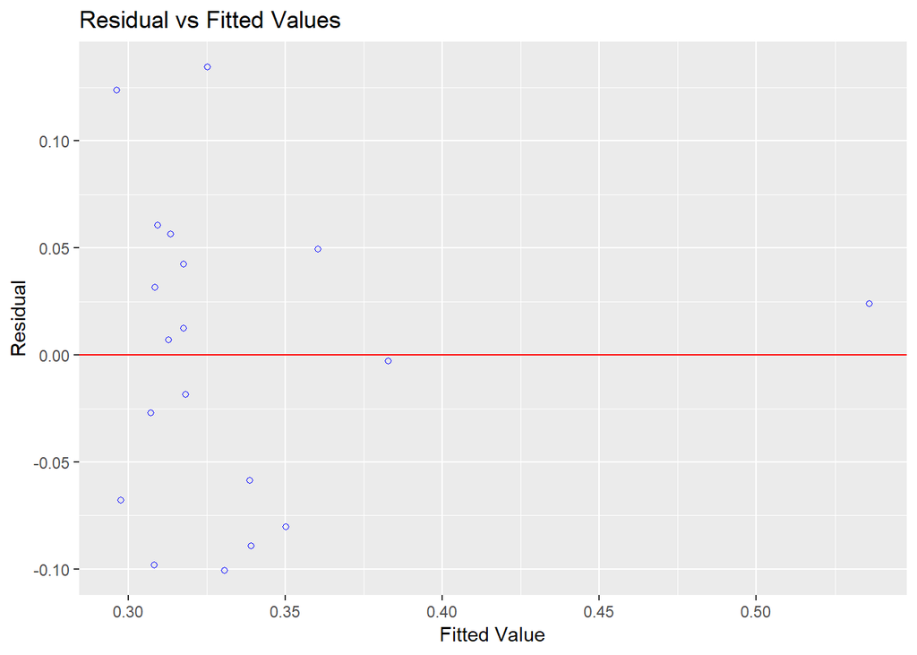

```r
ols_plot_resid_fit(fullRaw.lm)
```

Based on the plot above we see some sort of random scatter around zero but due to some fan-in shape homogenity can not be assumed.

### Question 2: Is there any multicollinearilty? Why?

In the question 1 itself we found there is a high possibility of multicollineartiy for our model data. Here we will check in details using statistics.

```r
ols_coll_diag(fullRaw.lm) # Produces both VIF and Condition Index
```

```
## Tolerance and Variance Inflation Factor
## ---------------------------------------
## # A tibble: 3 x 3
##   Variables Tolerance   VIF
##   <chr>         <dbl> <dbl>
## 1 bodyWT       0.0192 52.1
## 2 liverWT      0.749   1.34
## 3 dose         0.0194 51.4
##
##
## Eigenvalue and Condition Index
## ------------------------------
##     Eigenvalue Condition Index    intercept       bodyWT     liverWT
## 1 3.980955e+00         1.00000 0.0005211255 1.049346e-05 0.001061756
## 2 1.307262e-02        17.45068 0.0912614776 7.180392e-04 0.963765107
## 3 5.885352e-03        26.00803 0.8549633200 4.879743e-03 0.028213823
## 4 8.720917e-05       213.65475 0.0532540769 9.943917e-01 0.006959314
##           dose
## 1 1.138353e-05
## 2 8.095775e-04
## 3 6.508870e-03
## 4 9.926702e-01
```

The condition index is 213.65 > 30 and we have high VIF values (52 & 51). Hence we have multicollinearity for our model data.

### Question 3: Use RSTUDENT and Hat diag to check the outliers. And also use Cook’s D, DFFITS, and DFFBetas to do influence diagnostics.

a)Studentized Residual

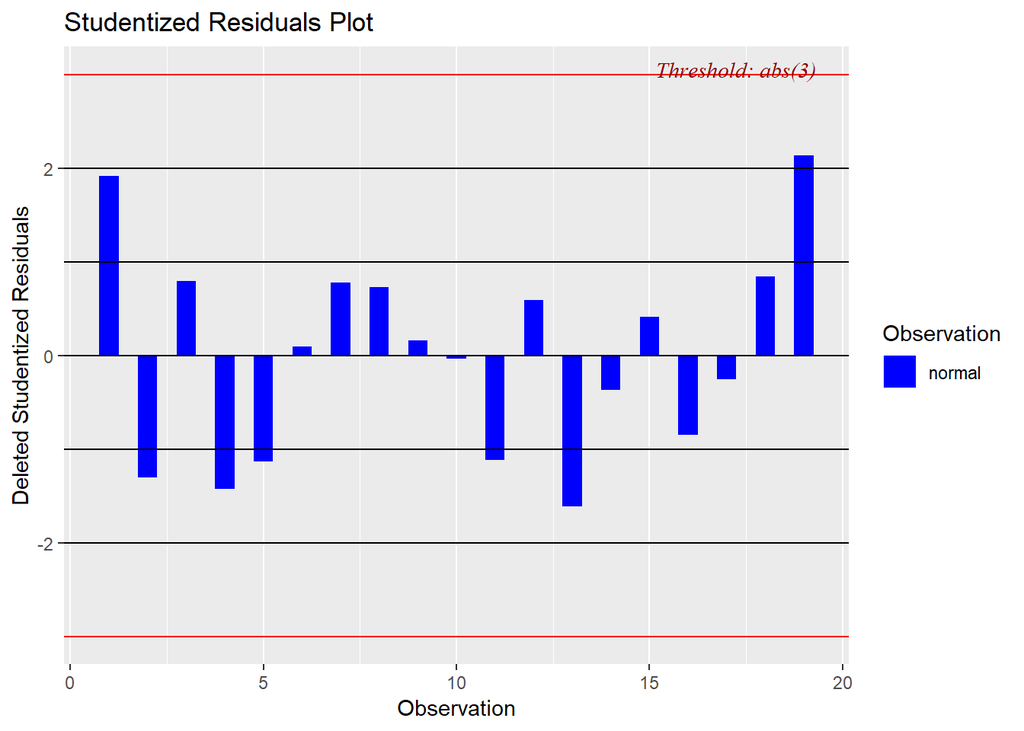

```r
StRes=ols_plot_resid_stud(fullRaw.lm) #Studentized Residual analysis - rstudent
```

```r
StRes$outlier
```

```
## # A tibble: 0 x 2
## # ... with 2 variables: observation <int>, stud_resid <dbl>
```

2. Below will list Hat Diag H, dffits and dfbetas. It also has cook’s d bar and cov.r. These statistics are usually used to detect possible outliers.  
   Astericks beside obs. denotes influential obs.

```r
# Get ALL INFLUENCE MEASURES DISCUSSED (DFFITS,DFBETAS,COOKSD,HAT diag)
influence.measures(fullRaw.lm)
```

```
## Influence measures of
##   lm(formula = Y ~ bodyWT + liverWT + dose, data = liver) :
##
##      dfb.1_ dfb.bdWT  dfb.lvWT dfb.dose   dffit cov.r   cook.d    hat inf
## 1  -0.03835  0.31492 -0.704363 -0.24375  0.8920 0.631 1.69e-01 0.1780
## 2   0.14256 -0.09774 -0.481778  0.12561 -0.6088 1.016 8.85e-02 0.1793
## 3  -0.23100 -1.66770  0.304572  1.74720  1.9048 7.401 9.30e-01 0.8509   *
## 4   0.12503 -0.12686 -0.303651  0.14009 -0.4944 0.860 5.72e-02 0.1076
## 5   0.52161 -0.39627  0.550016  0.27474 -0.9095 1.524 2.03e-01 0.3915
## 6   0.00229  0.01360  0.029003 -0.01715  0.0427 1.567 4.87e-04 0.1612
## 7  -0.18376  0.15044 -0.083355 -0.11839  0.3096 1.289 2.46e-02 0.1369
## 8  -0.29725  0.05936  0.246500 -0.04042  0.4262 1.520 4.69e-02 0.2537
## 9  -0.00968  0.01791  0.000168 -0.01673  0.0427 1.402 4.88e-04 0.0670
## 10 -0.00566  0.00993 -0.003365 -0.00929 -0.0140 1.496 5.23e-05 0.1197
## 11 -0.29053  0.19381  0.100742 -0.17288 -0.4104 1.066 4.14e-02 0.1195
## 12  0.21742 -0.02526  0.051721 -0.00920  0.2689 1.444 1.89e-02 0.1724
## 13 -0.77232  0.14391  0.766461 -0.12005 -1.0989 0.972 2.73e-01 0.3162
## 14 -0.03482 -0.04618 -0.076534  0.05990 -0.1423 1.461 5.37e-03 0.1314
## 15  0.01868  0.04063 -0.054603 -0.03817  0.1188 1.359 3.73e-03 0.0762
## 16  0.12309 -0.00557  0.328720 -0.04910 -0.4475 1.375 5.10e-02 0.2166
## 17 -0.10359  0.01454 -0.027611  0.00215 -0.1262 1.607 4.25e-03 0.1952
## 18 -0.15423  0.19035  0.162330 -0.18929  0.3522 1.270 3.16e-02 0.1487
## 19  0.85580 -0.25010 -0.294617  0.17123  0.9952 0.517 2.00e-01 0.1780
```

Now going by each one of the measures separately:

3. Cook’s d chart and analysis

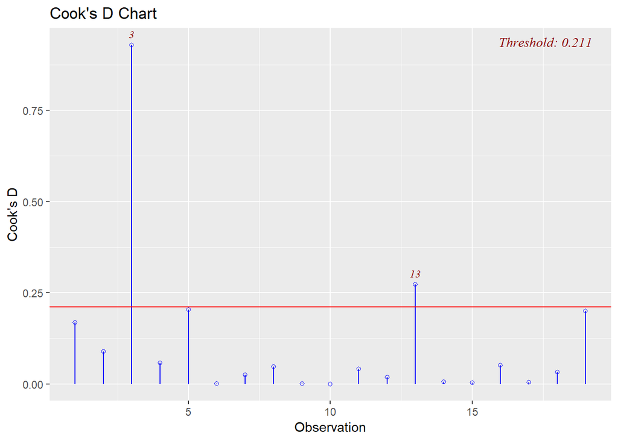

```r
CkDchart=ols_plot_cooksd_chart(fullRaw.lm) # Chart
```

```r
CkDchart$outliers
```

```
## # A tibble: 2 x 2
##   observation cooks_distance
##         <int>          <dbl>
## 1           3          0.930
## 2          13          0.273
```

4. To create the DFBETAs Panel we again ask ols to apply dfbetas analysis on our model as follows:

```r
Dfb = ols_plot_dfbetas(fullRaw.lm) #dfbetas analysis
Dfb$outlier
```

[output not shown]

5. To compute the Dffits one should use:

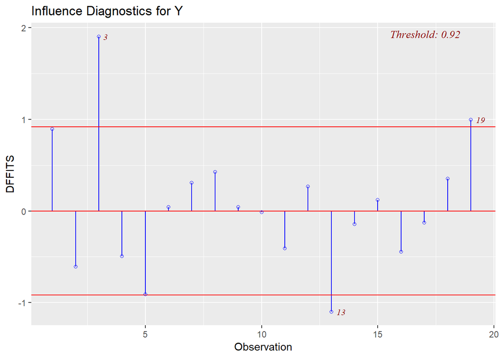

```r
Dff=ols_plot_dffits(fullRaw.lm) #dffites analysis
```

```r
Dff$outlier
```

```
## # A tibble: 3 x 2
##   observation dffits
##         <int>  <dbl>
## 1           3  1.90
## 2          13 -1.10
## 3          19  0.995
```

### Question 4: In the output there are two columns called “95% CL mean” and “95% CL Predicted”. Explain what their difference is.

```r
predict(fullRaw.lm, interval="prediction",level=0.95) #For prediction
```

```
##          fit       lwr       upr
## 1  0.2962420 0.1174389 0.4750451
## 2  0.3391362 0.1602300 0.5180423
## 3  0.5359118 0.3117824 0.7600412
## 4  0.3305573 0.1571768 0.5039378
## 5  0.2977119 0.1033759 0.4920479
## 6  0.3128688 0.1353470 0.4903905
## 7  0.3134197 0.1377636 0.4890758
## 8  0.3604159 0.1759577 0.5448742
## 9  0.3176891 0.1475159 0.4878622
## 10 0.3828445 0.2085218 0.5571672
## 11 0.3501463 0.1758377 0.5244549
## 12 0.3176423 0.1392636 0.4960209
## 13 0.3081511 0.1191502 0.4971520
## 14 0.3071429 0.1319102 0.4823755
## 15 0.3083853 0.1374833 0.4792873
## 16 0.3387547 0.1570433 0.5204661
## 17 0.3183538 0.1382469 0.4984607
## 18 0.3093177 0.1327492 0.4858861
## 19 0.3253088 0.1465072 0.5041103
```

```r
predict(fullRaw.lm, interval = 'confidence',level=0.95) #For mean
```

```
##          fit       lwr       upr
## 1  0.2962420 0.2267404 0.3657435
## 2  0.3391362 0.2693699 0.4089024
## 3  0.5359118 0.3839450 0.6878786
## 4  0.3305573 0.2765138 0.3846009
## 5  0.2977119 0.1946276 0.4007963
## 6  0.3128688 0.2467334 0.3790041
## 7  0.3134197 0.2524692 0.3743702
## 8  0.3604159 0.2774416 0.4433903
## 9  0.3176891 0.2750415 0.3603366
## 10 0.3828445 0.3258506 0.4398384
## 11 0.3501463 0.2931955 0.4070972
## 12 0.3176423 0.2492402 0.3860443
## 13 0.3081511 0.2155161 0.4007861
## 14 0.3071429 0.2474235 0.3668622
## 15 0.3083853 0.2629167 0.3538539
## 16 0.3387547 0.2620805 0.4154290
## 17 0.3183538 0.2455636 0.3911440
## 18 0.3093177 0.2457855 0.3728498
## 19 0.3253088 0.2558113 0.3948063
```

“95% CL Predicted” - It will give us prediction of a new observation. It will be more variable than mean CI, with a higher/thicker confidence band around regression line/point estimate.  
“95% CL mean” - It will give us estimation on mean response. It will be less variable than predicted value, with a lower/thinner confidence band around regression line/point estimate.

### Question 5: What is the partial R2 type II for the variable DOSE. Can it be used to evaluate the importance of DOSE?

```r
#' The @rsq.partial function is from the rsq pacakge
#' it takes the model object as its argument
#' it produces the partial R-Square type II
rsq.partial(fullRaw.lm)
```

```
## $adjustment
## [1] FALSE
##
## $variable
## [1] "bodyWT"  "liverWT" "dose"
##
## $partial.rsq
## [1] 0.32122893 0.04395606 0.33421029
```

For ‘dose’ the value is 0.3342. Yes, it can be used to evaluate the importance of ‘dose’ but a better statistics would be the p-value.

### Question 6: Carefully exam the values of standardized regression coefficients and partial R2 type II for individual independent variables, do you see the similar trends that you see in t-values in the t-test of regression coefficient? Make brief comments.

Standardize using Scale.

```r
liver_noNA <- na.omit(liver) # remove any NA rows
#' apply the @scale function to all columns in the @liver_noNA
#' dataset by using the @lapply function
#'
#' the lapply function produces a list of the variables
#' convert list to data frame by using the @as.data.frame function
#' Store transformerd dataset as liver_trans
liver_trans <- as.data.frame(lapply(liver_noNA, scale))
```

1. Standardized Regression Coefficients:

```r
# Fit the model with standardized coefficients
fullTrans.lm <- lm(Y ~ bodyWT+liverWT+dose, data=liver_trans)
summary(fullTrans.lm)
```

```
##
## Call:
## lm(formula = Y ~ bodyWT + liverWT + dose, data = liver_trans)
##
## Residuals:
##      Min       1Q   Median       3Q      Max
## -1.13667 -0.71477  0.08061  0.51964  1.52251
##
## Coefficients:
##               Estimate Std. Error t value Pr(>|t|)
## (Intercept)  1.716e-15  2.004e-01   0.000   1.0000
## bodyWT      -3.960e+00  1.486e+00  -2.664   0.0177 *
## liverWT      1.976e-01  2.380e-01   0.830   0.4193
## dose         4.052e+00  1.477e+00   2.744   0.0151 *
## ---
## Signif. codes:  0 '***' 0.001 '**' 0.01 '*' 0.05 '.' 0.1 ' ' 1
##
## Residual standard error: 0.8737 on 15 degrees of freedom
## Multiple R-squared:  0.3639, Adjusted R-squared:  0.2367
## F-statistic:  2.86 on 3 and 15 DF,  p-value: 0.07197
```

From the standardized Regression Coefficients above we can see the most important variable is dose with the highest value and the least important is the liverWT.

2. Partial R-Square type II:

```r
#' The @rsq.partial function is from the rsq pacakge
#' it takes the model object as its argument
#' it produces the partial R-Square type II
rsq.partial(fullRaw.lm)
```

```
## $adjustment
## [1] FALSE
##
## $variable
## [1] "bodyWT"  "liverWT" "dose"
##
## $partial.rsq
## [1] 0.32122893 0.04395606 0.33421029
```

From the partial R-Square type II above we can see the most important variable is dose with the highest value and the least important is the liverWT.

3. t-values in the t-test of regression coefficient:

```r
#' fit the full model without preprocessing the variables - hence raw vars
summary(fullRaw.lm)
```

```
##
## Call:
## lm(formula = Y ~ bodyWT + liverWT + dose, data = liver)
##
## Residuals:
##       Min        1Q    Median        3Q       Max
## -0.100557 -0.063233  0.007131  0.045971  0.134691
##
## Coefficients:
##              Estimate Std. Error t value Pr(>|t|)
## (Intercept)  0.265922   0.194585   1.367   0.1919
## bodyWT      -0.021246   0.007974  -2.664   0.0177 *
## liverWT      0.014298   0.017217   0.830   0.4193
## dose         4.178111   1.522625   2.744   0.0151 *
## ---
## Signif. codes:  0 '***' 0.001 '**' 0.01 '*' 0.05 '.' 0.1 ' ' 1
##
## Residual standard error: 0.07729 on 15 degrees of freedom
##   (1 observation deleted due to missingness)
## Multiple R-squared:  0.3639, Adjusted R-squared:  0.2367
## F-statistic:  2.86 on 3 and 15 DF,  p-value: 0.07197
```

From the p-value of t-statistics above we can see the most important variable is dose with the most significant value and the least important is the liverWT with no significance.

Finally, we can conclude as far as the importance of the variable is concerned, all three different statistical measures agree with each other.